# Project: Movie statistics

- Introduction
- Data Wrangling
- Data cleaning
- Exploratory Data Analysis
- Conclusions

## Introduction

The analysis of the data set "TMDb movies dataset" will be shown below. Some statistical data, min, max and average values, and the dependence of some indicators on others in the form of tables and graphs are shown.

The data set contained a set of movie data in the form of 10866 lines in 21 columns. During the analysis, uninformative columns were deleted, filled and sorted empty cells, some data types were converted.

## Research Questions:

1. Maximum, minimum and average films budget
2. Maximum, minimum and average films revenue
3. Maximum, minimum and average films profit
4. Most popular genres
5. Most popular actors
6. Most popular directors
7. TOP 10 Films rated
8. Most frequent runtime (hist)
9. Most frequent dates of release (graph)
10. Еhe dependence of the film's vote on the budget

```python
#importing necessary files and packages
import pandas as pd
import numpy as np
import matplotlib.pyplot as plt
import seaborn as sns
from datetime import datetime
% matplotlib inline
```

```python
#output in bold
from IPython.display import Markdown, display
def printmd(string):
    display(Markdown(string))
```

## Data Wrangling

Load and preparing of data for cleaning and analysis:

```python
df = pd.read_csv('tmdb-movies.csv')
df.head()
```

|  | id | imdb_id | popularity | budget | revenue | original_title | cast | homepage | director | tagline | ... | overview | runtime | genres | production_companies | release_date | vote_count | vote_average | release_year | budget_adj | revenue_adj |
| --- | --- | --- | --- | --- | --- | --- | --- | --- | --- | --- | --- | --- | --- | --- | --- | --- | --- | --- | --- | --- | --- |
| 0 | 135397 | tt0369610 | 32.985763 | 150000000 | 1513528810 | Jurassic World | Chris Pratt\|Bryce Dallas Howard\|Irrfan Khan\|Vi... | http://www.jurassicworld.com/ | Colin Trevorrow | The park is open. | ... | Twenty-two years after the events of Jurassic ... | 124 | Action\|Adventure\|Science Fiction\|Thriller | Universal Studios\|Amblin Entertainment\|Legenda... | 6/9/15 | 5562 | 6.5 | 2015 | 1.379999e+08 | 1.392446e+09 |
| 1 | 76341 | tt1392190 | 28.419936 | 150000000 | 378436354 | Mad Max: Fury Road | Tom Hardy\|Charlize Theron\|Hugh Keays-Byrne\|Nic... | http://www.madmaxmovie.com/ | George Miller | What a Lovely Day. | ... | An apocalyptic story set in the furthest reach... | 120 | Action\|Adventure\|Science Fiction\|Thriller | Village Roadshow Pictures\|Kennedy Miller Produ... | 5/13/15 | 6185 | 7.1 | 2015 | 1.379999e+08 | 3.481613e+08 |
| 2 | 262500 | tt2908446 | 13.112507 | 110000000 | 295238201 | Insurgent | Shailene Woodley\|Theo James\|Kate Winslet\|Ansel... | http://www.thedivergentseries.movie/#insurgent | Robert Schwentke | One Choice Can Destroy You | ... | Beatrice Prior must confront her inner demons ... | 119 | Adventure\|Science Fiction\|Thriller | Summit Entertainment\|Mandeville Films\|Red Wago... | 3/18/15 | 2480 | 6.3 | 2015 | 1.012000e+08 | 2.716190e+08 |
| 3 | 140607 | tt2488496 | 11.173104 | 200000000 | 2068178225 | Star Wars: The Force Awakens | Harrison Ford\|Mark Hamill\|Carrie Fisher\|Adam D... | http://www.starwars.com/films/star-wars-episod... | J.J. Abrams | Every generation has a story. | ... | Thirty years after defeating the Galactic Empi... | 136 | Action\|Adventure\|Science Fiction\|Fantasy | Lucasfilm\|Truenorth Productions\|Bad Robot | 12/15/15 | 5292 | 7.5 | 2015 | 1.839999e+08 | 1.902723e+09 |
| 4 | 168259 | tt2820852 | 9.335014 | 190000000 | 1506249360 | Furious 7 | Vin Diesel\|Paul Walker\|Jason Statham\|Michelle ... | http://www.furious7.com/ | James Wan | Vengeance Hits Home | ... | Deckard Shaw seeks revenge against Dominic Tor... | 137 | Action\|Crime\|Thriller | Universal Pictures\|Original Film\|Media Rights ... | 4/1/15 | 2947 | 7.3 | 2015 | 1.747999e+08 | 1.385749e+09 |

5 rows × 21 columns

```python
#dataset info
df.shape
```

```
(10866, 21)
```

```python
df.describe()
```

|  | id | popularity | budget | revenue | runtime | vote_count | vote_average | release_year | budget_adj | revenue_adj |
| --- | --- | --- | --- | --- | --- | --- | --- | --- | --- | --- |
| count | 10866.000000 | 10866.000000 | 1.086600e+04 | 1.086600e+04 | 10866.000000 | 10866.000000 | 10866.000000 | 10866.000000 | 1.086600e+04 | 1.086600e+04 |
| mean | 66064.177434 | 0.646441 | 1.462570e+07 | 3.982332e+07 | 102.070863 | 217.389748 | 5.974922 | 2001.322658 | 1.755104e+07 | 5.136436e+07 |
| std | 92130.136561 | 1.000185 | 3.091321e+07 | 1.170035e+08 | 31.381405 | 575.619058 | 0.935142 | 12.812941 | 3.430616e+07 | 1.446325e+08 |
| min | 5.000000 | 0.000065 | 0.000000e+00 | 0.000000e+00 | 0.000000 | 10.000000 | 1.500000 | 1960.000000 | 0.000000e+00 | 0.000000e+00 |
| 25% | 10596.250000 | 0.207583 | 0.000000e+00 | 0.000000e+00 | 90.000000 | 17.000000 | 5.400000 | 1995.000000 | 0.000000e+00 | 0.000000e+00 |
| 50% | 20669.000000 | 0.383856 | 0.000000e+00 | 0.000000e+00 | 99.000000 | 38.000000 | 6.000000 | 2006.000000 | 0.000000e+00 | 0.000000e+00 |
| 75% | 75610.000000 | 0.713817 | 1.500000e+07 | 2.400000e+07 | 111.000000 | 145.750000 | 6.600000 | 2011.000000 | 2.085325e+07 | 3.369710e+07 |
| max | 417859.000000 | 32.985763 | 4.250000e+08 | 2.781506e+09 | 900.000000 | 9767.000000 | 9.200000 | 2015.000000 | 4.250000e+08 | 2.827124e+09 |

```python
df.info()
```

```
<class 'pandas.core.frame.DataFrame'>
RangeIndex: 10866 entries, 0 to 10865
Data columns (total 21 columns):
id                      10866 non-null int64
imdb_id                 10856 non-null object
popularity              10866 non-null float64
budget                  10866 non-null int64
revenue                 10866 non-null int64
original_title          10866 non-null object
cast                    10790 non-null object
homepage                2936 non-null object
director                10822 non-null object
tagline                 8042 non-null object
keywords                9373 non-null object
overview                10862 non-null object
runtime                 10866 non-null int64
genres                  10843 non-null object
production_companies    9836 non-null object
release_date            10866 non-null object
vote_count              10866 non-null int64
vote_average            10866 non-null float64
release_year            10866 non-null int64
budget_adj              10866 non-null float64
revenue_adj             10866 non-null float64
dtypes: float64(4), int64(6), object(11)
memory usage: 1.7+ MB
```

## Data Cleaning

1. Removing unused and uninformative columns
2. Adding new columns needed to answer research questions
3. Filling or deleting empty cells and values with "NAN"
4. Сonverting data to the required formats

```python
#Deleting unusing columns
df.drop(['id', 'imdb_id', 'popularity', 'homepage', 'keywords', 'overview', 'vote_count', 'budget_adj', 'revenue_adj'], axis=1, inplace=True)
```

```python
#Create a new column
df['profit'] = df['revenue'] - df['budget']
```

```python
#cleaning and transformation of zero values and "NAN"
df['budget'] = df['budget'].replace(0, np.nan)
```

```python
df['revenue'] = df['revenue'].replace(0, np.nan)
```

```python
df['runtime'] = df['runtime'].replace(0, np.nan)
```

```python
df.dropna(subset = ['budget', 'revenue', 'runtime'], inplace = True)
```

```python
#deleting unreliable information
df.drop(df[df.revenue < 1000].index, inplace=True)
```

```python
df.drop(df[df.budget < 1000].index, inplace=True)
```

```python
rows, col = df.shape
```

```python
#cnanging of data format
df.release_date = pd.to_datetime(df['release_date'])
```

```python
df['budget'] = df['budget'].apply(np.int64)
```

```python
df['revenue'] = df['revenue'].apply(np.int64)
```

```python
df.dtypes
```

```
budget                           int64
revenue                          int64
original_title                  object
cast                            object
director                        object
tagline                         object
runtime                        float64
genres                          object
production_companies            object
release_date            datetime64[ns]
vote_average                   float64
release_year                     int64
profit                           int64
dtype: object
```

## Exploratory Data Analysis

### Research Question 1: Maximum, Minimum and Average films budget

```python
printmd("**Movie with a Maximum budget:**")
```

**Movie with a Maximum budget:**

```python
print("\n", df.loc[df['budget'].idxmax()])
```

```
 budget                                                          425000000
revenue                                                          11087569
original_title                                          The Warrior's Way
cast                    Kate Bosworth|Jang Dong-gun|Geoffrey Rush|Dann...
director                                                       Sngmoo Lee
tagline                                           Assassin. Hero. Legend.
runtime                                                               100
genres                          Adventure|Fantasy|Action|Western|Thriller
production_companies                             Boram Entertainment Inc.
release_date                                          2010-12-02 00:00:00
vote_average                                                          6.4
release_year                                                         2010
profit                                                         -413912431
Name: 2244, dtype: object
```

```python
printmd("**Movie with a Minimum budget:**")
```

**Movie with a Minimum budget:**

```python
print("\n", df.loc[df['budget'].idxmin()])
```

```
 budget                                     6000
revenue                                    6000
original_title          Loose Change: Final Cut
cast                                        NaN
director                            Dylan Avery
tagline                                     NaN
runtime                                     129
genres                              Documentary
production_companies          Louder Than Words
release_date                2007-11-11 00:00:00
vote_average                                5.1
release_year                               2007
profit                                        0
Name: 7813, dtype: object
```

```python
printmd("**Average budget of movies:**")
```

**Average budget of movies:**

```python
print(int(df['budget'].mean()))
```

```
37460064
```

### Research Question 2: Maximum, Minimum and Average films revenue

```python
printmd("**Movie with a Maximum revenue:**")
```

**Movie with a Maximum revenue:**

```python
print("\n", df.loc[df['revenue'].idxmax()])
```

```
 budget                                                          237000000
revenue                                                        2781505847
original_title                                                     Avatar
cast                    Sam Worthington|Zoe Saldana|Sigourney Weaver|S...
director                                                    James Cameron
tagline                                       Enter the World of Pandora.
runtime                                                               162
genres                           Action|Adventure|Fantasy|Science Fiction
production_companies    Ingenious Film Partners|Twentieth Century Fox ...
release_date                                          2009-12-10 00:00:00
vote_average                                                          7.1
release_year                                                         2009
profit                                                         2544505847
Name: 1386, dtype: object
```

```python
printmd("**Movie with a Minimum revenue:**")
```

**Movie with a Minimum revenue:**

```python
print(df.loc[df['revenue'].idxmin()])
```

```
budget                                                            1500000
revenue                                                              1938
original_title                                              Best Man Down
cast                    Justin Long|Jess Weixler|Tyler Labine|Addison ...
director                                                       Ted Koland
tagline                                                               NaN
runtime                                                                90
genres                                                       Comedy|Drama
production_companies                                   KODA Entertainment
release_date                                          2012-10-20 00:00:00
vote_average                                                          5.9
release_year                                                         2012
profit                                                           -1498062
Name: 4668, dtype: object
```

```python
printmd("**Average revenue of movies:**")
```

**Average revenue of movies:**

```python
print(int(df['revenue'].mean()))
```

```
108612795
```

### Research Question 3: Maximum, Minimum and Average films profit

```python
printmd("**Movie with a Maximum profit:**")
```

**Movie with a Maximum profit:**

```python
print("\n", df.loc[df['profit'].idxmax()])
```

```
 budget                                                          237000000
revenue                                                        2781505847
original_title                                                     Avatar
cast                    Sam Worthington|Zoe Saldana|Sigourney Weaver|S...
director                                                    James Cameron
tagline                                       Enter the World of Pandora.
runtime                                                               162
genres                           Action|Adventure|Fantasy|Science Fiction
production_companies    Ingenious Film Partners|Twentieth Century Fox ...
release_date                                          2009-12-10 00:00:00
vote_average                                                          7.1
release_year                                                         2009
profit                                                         2544505847
Name: 1386, dtype: object
```

```python
printmd("**Movie with a Minimum profit:**")
```

**Movie with a Minimum profit:**

```python
print("\n", df.loc[df['profit'].idxmin()])
```

```
 budget                                                          425000000
revenue                                                          11087569
original_title                                          The Warrior's Way
cast                    Kate Bosworth|Jang Dong-gun|Geoffrey Rush|Dann...
director                                                       Sngmoo Lee
tagline                                           Assassin. Hero. Legend.
runtime                                                               100
genres                          Adventure|Fantasy|Action|Western|Thriller
production_companies                             Boram Entertainment Inc.
release_date                                          2010-12-02 00:00:00
vote_average                                                          6.4
release_year                                                         2010
profit                                                         -413912431
Name: 2244, dtype: object
```

```python
printmd("**Average profit of movies:**")
```

**Average profit of movies:**

```python
print(int(df['profit'].mean()))
```

```
71152730
```

### Research Question 4: Most popular genres

```python
#Create a function to determine the most frequent value in the input column
def df_date(column):
    column_data = df[column].str.cat(sep = '|')
    column_data = pd.Series(column_data.split('|'))
    count = column_data.value_counts(ascending = False)
    return count
```

```python
popular_genres = df_date('genres')
popular_genres.head()
```

```
Drama        1745
Comedy       1340
Thriller     1195
Action       1077
Adventure     743
dtype: int64
```

### Research Question 5: Most popular directors

```python
popular_director = df_date('director')
popular_director.head()
```

```
Steven Spielberg    28
Clint Eastwood      24
Ridley Scott        21
Woody Allen         18
Tim Burton          17
dtype: int64
```

### Research Question 6: Most popular actors

```python
popular_cast = df_date('cast')
popular_cast.head()
```

```
Robert De Niro       52
Bruce Willis         46
Nicolas Cage         43
Samuel L. Jackson    43
Matt Damon           36
dtype: int64
```

### Research Question 7: TOP 10 films rated

```python
#grading the vote from higher to least. First 10
top_10 = df.sort_values(['vote_average'], ascending = False)
top_10.head(10)
```

|  | budget | revenue | original_title | cast | director | tagline | runtime | genres | production_companies | release_date | vote_average | release_year | profit |
| --- | --- | --- | --- | --- | --- | --- | --- | --- | --- | --- | --- | --- | --- |
| 7948 | 1200000 | 4978922 | Stop Making Sense | David Byrne\|Tina Weymouth\|Chris Frantz\|Jerry H... | Jonathan Demme | Why stop making sense? Why a movie? Why a big ... | 88.0 | Documentary\|Music | Talking Heads\|Arnold Stiefel Company | 1984-11-16 | 8.4 | 1984 | 3778922 |
| 4178 | 25000000 | 28341469 | The Shawshank Redemption | Tim Robbins\|Morgan Freeman\|Bob Gunton\|William ... | Frank Darabont | Fear can hold you prisoner. Hope can set you f... | 142.0 | Drama\|Crime | Castle Rock Entertainment | 1994-09-10 | 8.4 | 1994 | 3341469 |
| 7269 | 6000000 | 245066411 | The Godfather | Marlon Brando\|Al Pacino\|James Caan\|Richard S. ... | Francis Ford Coppola | An offer you can't refuse. | 175.0 | Drama\|Crime | Paramount Pictures\|Alfran Productions | 1972-03-15 | 8.3 | 1972 | 239066411 |
| 650 | 3300000 | 13993093 | Whiplash | Miles Teller\|J.K. Simmons\|Melissa Benoist\|Aust... | Damien Chazelle | The road to greatness can take you to the edge. | 105.0 | Drama\|Music | Bold Films\|Blumhouse Productions\|Right of Way ... | 2014-10-10 | 8.2 | 2014 | 10693093 |
| 4177 | 8000000 | 213928762 | Pulp Fiction | John Travolta\|Samuel L. Jackson\|Uma Thurman\|Br... | Quentin Tarantino | Just because you are a character doesn't mean ... | 154.0 | Thriller\|Crime | Miramax Films\|A Band Apart\|Jersey Films | 1994-10-14 | 8.1 | 1994 | 205928762 |
| 2409 | 63000000 | 100853753 | Fight Club | Edward Norton\|Brad Pitt\|Meat Loaf\|Jared Leto\|H... | David Fincher | How much can you know about yourself if you've... | 139.0 | Drama | Regency Enterprises\|Fox 2000 Pictures\|Taurus F... | 1999-10-14 | 8.1 | 1999 | 37853753 |
| 4179 | 55000000 | 677945399 | Forrest Gump | Tom Hanks\|Robin Wright\|Gary Sinise\|Mykelti Wil... | Robert Zemeckis | The world will never be the same, once you've ... | 142.0 | Comedy\|Drama\|Romance | Paramount Pictures | 1994-07-06 | 8.1 | 1994 | 622945399 |
| 10222 | 22000000 | 321265768 | Schindler's List | Liam Neeson\|Ben Kingsley\|Ralph Fiennes\|Carolin... | Steven Spielberg | Whoever saves one life, saves the world entire. | 195.0 | Drama\|History\|War | Universal Pictures\|Amblin Entertainment | 1993-11-29 | 8.1 | 1993 | 299265768 |
| 2875 | 185000000 | 1001921825 | The Dark Knight | Christian Bale\|Michael Caine\|Heath Ledger\|Aaro... | Christopher Nolan | Why So Serious? | 152.0 | Drama\|Action\|Crime\|Thriller | DC Comics\|Legendary Pictures\|Warner Bros.\|Syncopy | 2008-07-16 | 8.1 | 2008 | 816921825 |
| 9758 | 13000000 | 47542841 | The Godfather: Part II | Al Pacino\|Robert Duvall\|Diane Keaton\|Robert De... | Francis Ford Coppola | I don't feel I have to wipe everybody out, Tom... | 200.0 | Drama\|Crime | Paramount Pictures\|The Coppola Company | 1974-12-20 | 8.1 | 1974 | 34542841 |

### Research Question 8: Most frequent runtime (hist)

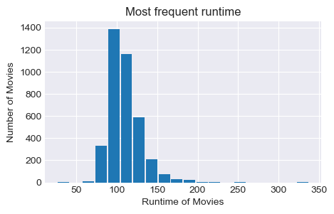

```python
#chaging the label size and chart visualization
plt.rc('xtick', labelsize = 10)
plt.rc('ytick', labelsize = 10)
sns.set_style('darkgrid')

#changing the figure size
plt.figure(figsize=(5,3), dpi = 100)
#giving a histogram plot
plt.hist(df['runtime'], rwidth = 0.9, bins =20)
#displays the plot
plt.ylabel('runtime')
#title
plt.title('Most frequent runtime')
#Y axis name
plt.ylabel('Number of Movies')
#X axis name
plt.xlabel('Runtime of Movies')
plt.show()
```

### Research Question 9: Most frequent date of release

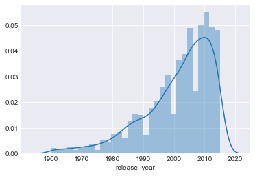

```python
sns.distplot(df.release_year)
```

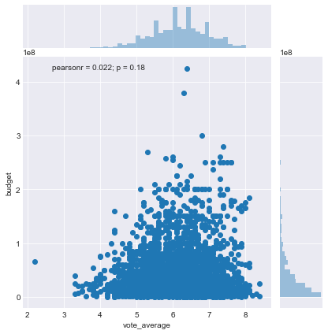

```python
#application of visualization Seaborn
sns.jointplot(df.vote_average, df.budget)
```

## Conclusions

I think the most useful for users will be to make a forecast about the quality of the newly appeared film, based on its actors, budget and director.